# HNLC_Metal_limitation

2026-04-23

#Load Librarys all librarys being used in this

```r
library(tidyverse)
library(sf)
library(terra)
```

```r
library(fs)
library(lubridate)
library(ggplot2)
library(ggspatial)
library(RColorBrewer)
library(maps)
library(patchwork)
library(readr)
library(dplyr)
library(writexl)
library(openxlsx)
library(FSA)
library(multcompView)
library(patchwork)
```

# Load in EPA and Metal data

All data loaded in for both EPA and metal data

Citation for EPA data U.S. Environmental Protection Agency. 2021. National Aquatic Resource Surveys: National Rivers and Streams Assessment 2018–2019 (Data and Metadata Files). U.S. Environmental Protection Agency, Office of Water Regulations and Standards, Criteria and Standards Division. https://www.epa.gov/national-aquatic-resource-surveys/data-national-aquatic-resource-surveys

```r
waterchem <- read.csv("./data/River_stream_18_19_water_chemistry_data.csv")
chlorophyll <- read.csv("./data/River_stream_18_19_water_chlorophyll_a.csv")
SiteInfo <- read.csv("./data/River_stream_18_19_siteInfo_data.csv")
Landscape <- read_csv("data/River_stream_18_19_Landscape.csv")
```

```r
us_states <- map_data("state")
Iron <- read.csv("./data/Iron_aggregated_high_quality_start2000_cleaned.csv")
Manganese <- read.csv("./data/Manganese_aggregated_high_quality_start2000_cleaned.csv")
Nickel <- read.csv("./data/Nickel_aggregated_high_quality_start2000_cleaned.csv")
Zinc <- read_csv("data/Zinc_aggregated_high_quality_start2000_cleaned.csv")
us_states <- map_data("state")
```

#clean EPA data keep site info Phoruspos and nitroggen results

```r
waterchem_clean <- waterchem %>%
  select(
    SITE_ID, VISIT_NO, DATE_COL,
    AMMONIA_N_RESULT, AMMONIA_N_UNITS,
    NITRATE_N_RESULT,NITRATE_N_UNITS,
    NITRITE_N_RESULT,NITRITE_N_UNITS,
    NITRATE_NITRITE_N_RESULT,NITRATE_NITRITE_N_UNITS,
    NTL_RESULT,NTL_UNITS,
    NTL_DISS_RESULT,NTL_DISS_UNITS,
    TKN_RESULT,TKN_UNITS,
    PTL_RESULT,PTL_UNITS,
    PTL_DISS_RESULT,PTL_DISS_UNITS
  )
chlorophyll_clean <- chlorophyll %>%
  select(
    SITE_ID, VISIT_NO,DATE_COL,
    CHLA_RESULT = RESULT, CHLA_UNITS = RESULT_UNITS
  )
SiteInfo <- SiteInfo %>%
  mutate(
    VISIT_NO = as.character(VISIT_NO), DATE_COL = as.character(DATE_COL)
  )
waterchem_clean <- waterchem_clean %>%
  mutate(
    VISIT_NO = as.character(VISIT_NO), DATE_COL = as.character(DATE_COL)
  )
chlorophyll_clean <- chlorophyll_clean %>%
  mutate(
    VISIT_NO = as.character(VISIT_NO), DATE_COL = as.character(DATE_COL)
  )
combined_data <- SiteInfo
combined_data <- combined_data %>% left_join(waterchem_clean,
                                             by = c("SITE_ID","VISIT_NO","DATE_COL"))
combined_data <- combined_data %>% left_join(chlorophyll_clean,
                                             by = c("SITE_ID","VISIT_NO","DATE_COL"))
#THE BIG DADDY OF DATA SETS
HNLC_data <- combined_data

#removes negative values (not possible)
HNLC_data <- HNLC_data %>%
  mutate( PTL_RESULT = ifelse(!is.na(PTL_RESULT) & PTL_RESULT < 0, 0, PTL_RESULT),
    PTL_DISS_RESULT = ifelse(!is.na(PTL_DISS_RESULT) & PTL_DISS_RESULT < 0, 0, PTL_DISS_RESULT))
```

#Clean Metal data

obtained only the 2018 and 2019 years of metal data

```r
Iron_2018_2019 <- Iron %>%
  mutate(ActivityStartDate = as.Date(ActivityStartDate)) %>%
  filter(year(ActivityStartDate) %in% c(2018, 2019))

Manganese_2018_2019 <- Manganese %>%
  mutate(ActivityStartDate = as.Date(ActivityStartDate)) %>%
  filter(year(ActivityStartDate) %in% c(2018, 2019))

Nickel_2018_2019 <- Nickel %>%
  mutate(ActivityStartDate = as.Date(ActivityStartDate)) %>%
  filter(year(ActivityStartDate) %in% c(2018, 2019))

Zinc_2018_2019 <- Zinc %>%
  mutate(ActivityStartDate = as.Date(ActivityStartDate)) %>%
  filter(year(ActivityStartDate) %in% c(2018, 2019))
```

#HNLC by eco 9 regions

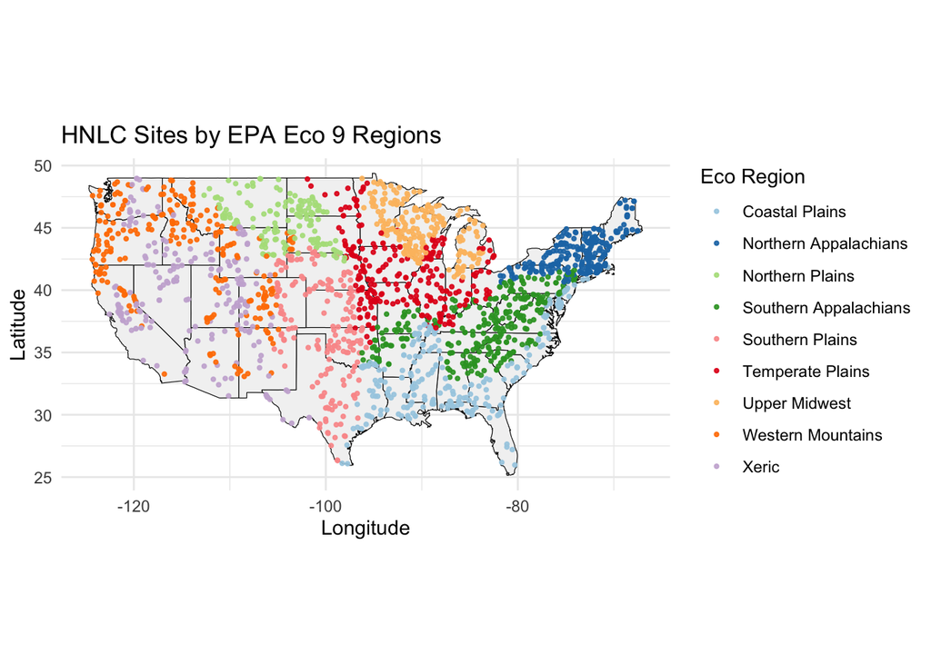

```r
#ECOREGIONS AG_ECO9

us_map <- map_data("state")
# Plot all sites according to eco region color AG_ECO9_NM
ggplot() +
  geom_polygon(data = us_map,
               aes(x = long, y = lat, group = group),
               fill = "gray95", color = "black",linewidth = 0.2) +
  geom_point(data = HNLC_data,
             aes(x = LON_DD83, y = LAT_DD83, color = AG_ECO9_NM),
             size = 0.75, alpha = 0.9) +
  scale_color_brewer(palette = "Paired") +
  coord_fixed(1.3) +
  theme_minimal() +
  labs(title = "HNLC Sites by EPA Eco 9 Regions",
       x = "Longitude",
       y = "Latitude",
       color = "Eco Region")
```

```r
#figure out what level of ecoreigon to use
HNLC_data %>% summarise(num_ecoregions = n_distinct(AG_ECO9_NM))
```

```
##   num_ecoregions
## 1              9
```

```r
unique(HNLC_data$AG_ECO9_NM)
```

```
## [1] "Southern Plains"       "Temperate Plains"      "Coastal Plains"
## [4] "Upper Midwest"         "Southern Appalachians" "Northern Appalachians"
## [7] "Western Mountains"     "Northern Plains"       "Xeric"
```

```r
unique(HNLC_data$AG_ECO9)
```

```
## [1] "SPL" "TPL" "CPL" "UMW" "SAP" "NAP" "WMT" "NPL" "XER"
```

```r
#split into 9 ecoreigns
SPL <- subset(HNLC_data, AG_ECO9 == "SPL") #southern plains
TPL <- subset(HNLC_data, AG_ECO9 == "TPL") #temperate plains
CPL <- subset(HNLC_data, AG_ECO9 == "CPL") #Coastal Plains
UMW <- subset(HNLC_data, AG_ECO9 == "UMW") #upper midwest
SAP <- subset(HNLC_data, AG_ECO9 == "SAP") #Southern Appalachians
NAP <- subset(HNLC_data, AG_ECO9 == "NAP") #Northern Appalachians
WMT <- subset(HNLC_data, AG_ECO9 == "WMT") #Western Mountains
NPL <- subset(HNLC_data, AG_ECO9 == "NPL") #Northern Plains
XER <- subset(HNLC_data, AG_ECO9 == "XER") #Xeric

#find high nutrients and low chrollyphl/ low perphyton for each ECOreign 9 ----


##Southern Plains SPL ----
# determine sites with High nutrients low chlorophyll
# Calculate thresholds (top quartile nutrients, bottom quartile chlorophyll/periphyton)
P75_SPL <- quantile(SPL$PTL_RESULT, 0.75, na.rm = TRUE)
N75_SPL <- quantile(SPL$NTL_RESULT, 0.75, na.rm = TRUE)
C25_SPL <- quantile(SPL$CHLA_RESULT, 0.25, na.rm = TRUE)
# sites with low chlorophyll and periphyton
low_chl_sites_SPL <- SPL %>% dplyr::filter(CHLA_RESULT <= C25_SPL)
# classify nutrient conditions for chlorophyll sites
HNLChlorophyll_sites_SPL <- low_chl_sites_SPL %>%
  dplyr::mutate(
    nutrient_group = dplyr::case_when(
      PTL_RESULT >= P75_SPL & NTL_RESULT >= N75_SPL ~ "High N + High P",
      PTL_RESULT >= P75_SPL & NTL_RESULT < N75_SPL ~ "High P only",
      NTL_RESULT >= N75_SPL & PTL_RESULT < P75_SPL ~ "High N only",
      TRUE ~ NA_character_
    )
  ) %>%
  dplyr::filter(!is.na(nutrient_group))


## Temperate plains TPL ----
# determine sites with High nutrients low chlorophyll
# Calculate thresholds (top quartile nutrients, bottom quartile chlorophyll/periphyton)
P75_TPL <- quantile(TPL$PTL_RESULT, 0.75, na.rm = TRUE)
N75_TPL <- quantile(TPL$NTL_RESULT, 0.75, na.rm = TRUE)
C25_TPL <- quantile(TPL$CHLA_RESULT, 0.25, na.rm = TRUE)

# sites with low chlorophyll and periphyton
low_chl_sites_TPL <- TPL %>% dplyr::filter(CHLA_RESULT <= C25_TPL)

# classify nutrient conditions for chlorophyll sites
HNLChlorophyll_sites_TPL <- low_chl_sites_TPL %>%
  dplyr::mutate(
    nutrient_group = dplyr::case_when(
      PTL_RESULT >= P75_TPL & NTL_RESULT >= N75_TPL ~ "High N + High P",
      PTL_RESULT >= P75_TPL & NTL_RESULT < N75_TPL ~ "High P only",
      NTL_RESULT >= N75_TPL & PTL_RESULT < P75_TPL ~ "High N only",
      TRUE ~ NA_character_
    )
  ) %>%
  dplyr::filter(!is.na(nutrient_group))

##Coastal plains CPL----
# determine sites with High nutrients low chlorophyll
# Calculate thresholds (top quartile nutrients, bottom quartile chlorophyll/periphyton)
P75_CPL <- quantile(CPL$PTL_RESULT, 0.75, na.rm = TRUE)
N75_CPL <- quantile(CPL$NTL_RESULT, 0.75, na.rm = TRUE)
C25_CPL <- quantile(CPL$CHLA_RESULT, 0.25, na.rm = TRUE)
# sites with low chlorophyll and periphyton
low_chl_sites_CPL <- CPL %>% dplyr::filter(CHLA_RESULT <= C25_CPL)

# classify nutrient conditions for chlorophyll sites
HNLChlorophyll_sites_CPL <- low_chl_sites_CPL %>%
  dplyr::mutate(
    nutrient_group = dplyr::case_when(
      PTL_RESULT >= P75_CPL & NTL_RESULT >= N75_CPL ~ "High N + High P",
      PTL_RESULT >= P75_CPL & NTL_RESULT < N75_CPL ~ "High P only",
      NTL_RESULT >= N75_CPL & PTL_RESULT < P75_CPL ~ "High N only",
      TRUE ~ NA_character_
    )
  ) %>%
  dplyr::filter(!is.na(nutrient_group))




##Upper Midwest UMW ----
# determine sites with High nutrients low chlorophyll
# Calculate thresholds (top quartile nutrients, bottom quartile chlorophyll/periphyton)
P75_UMW <- quantile(UMW$PTL_RESULT, 0.75, na.rm = TRUE)
N75_UMW <- quantile(UMW$NTL_RESULT, 0.75, na.rm = TRUE)
C25_UMW <- quantile(UMW$CHLA_RESULT, 0.25, na.rm = TRUE)

# sites with low chlorophyll and periphyton
low_chl_sites_UMW <- UMW %>% dplyr::filter(CHLA_RESULT <= C25_UMW)

# classify nutrient conditions for chlorophyll sites
HNLChlorophyll_sites_UMW <- low_chl_sites_UMW %>%
  dplyr::mutate(
    nutrient_group = dplyr::case_when(
      PTL_RESULT >= P75_UMW & NTL_RESULT >= N75_UMW ~ "High N + High P",
      PTL_RESULT >= P75_UMW & NTL_RESULT < N75_UMW ~ "High P only",
      NTL_RESULT >= N75_UMW & PTL_RESULT < P75_UMW ~ "High N only",
      TRUE ~ NA_character_
    )
  ) %>%
  dplyr::filter(!is.na(nutrient_group))

##Southern Appalachians SAP ----
# determine sites with High nutrients low chlorophyll
# Calculate thresholds (top quartile nutrients, bottom quartile chlorophyll/periphyton)
P75_SAP <- quantile(SAP$PTL_RESULT, 0.75, na.rm = TRUE)
N75_SAP <- quantile(SAP$NTL_RESULT, 0.75, na.rm = TRUE)
C25_SAP <- quantile(SAP$CHLA_RESULT, 0.25, na.rm = TRUE)

# sites with low chlorophyll and periphyton
low_chl_sites_SAP <- SAP %>% dplyr::filter(CHLA_RESULT <= C25_SPL)

# classify nutrient conditions for chlorophyll sites
HNLChlorophyll_sites_SAP <- low_chl_sites_SAP %>%
  dplyr::mutate(
    nutrient_group = dplyr::case_when(
      PTL_RESULT >= P75_SAP & NTL_RESULT >= N75_SAP ~ "High N + High P",
      PTL_RESULT >= P75_SAP & NTL_RESULT < N75_SAP ~ "High P only",
      NTL_RESULT >= N75_SAP & PTL_RESULT < P75_SAP ~ "High N only",
      TRUE ~ NA_character_
    )
  ) %>%
  dplyr::filter(!is.na(nutrient_group))


##Northern Appalachians NAP ----
# determine sites with High nutrients low chlorophyll
# Calculate thresholds (top quartile nutrients, bottom quartile chlorophyll/periphyton)
P75_NAP <- quantile(NAP$PTL_RESULT, 0.75, na.rm = TRUE)
N75_NAP <- quantile(NAP$NTL_RESULT, 0.75, na.rm = TRUE)
C25_NAP <- quantile(NAP$CHLA_RESULT, 0.25, na.rm = TRUE)

# sites with low chlorophyll and periphyton
low_chl_sites_NAP <- NAP %>% dplyr::filter(CHLA_RESULT <= C25_NAP)

# classify nutrient conditions for chlorophyll sites
HNLChlorophyll_sites_NAP <- low_chl_sites_NAP %>%
  dplyr::mutate(
    nutrient_group = dplyr::case_when(
      PTL_RESULT >= P75_NAP & NTL_RESULT >= N75_NAP ~ "High N + High P",
      PTL_RESULT >= P75_NAP & NTL_RESULT < N75_NAP ~ "High P only",
      NTL_RESULT >= N75_NAP & PTL_RESULT < P75_NAP ~ "High N only",
      TRUE ~ NA_character_
    )
  ) %>%
  dplyr::filter(!is.na(nutrient_group))


##Western Mountains WMT----
# determine sites with High nutrients low chlorophyll
# Calculate thresholds (top quartile nutrients, bottom quartile chlorophyll/periphyton)
P75_WMT <- quantile(WMT$PTL_RESULT, 0.75, na.rm = TRUE)
N75_WMT <- quantile(WMT$NTL_RESULT, 0.75, na.rm = TRUE)
C25_WMT <- quantile(WMT$CHLA_RESULT, 0.25, na.rm = TRUE)

# sites with low chlorophyll and periphyton
low_chl_sites_WMT <- WMT %>% dplyr::filter(CHLA_RESULT <= C25_WMT)

# classify nutrient conditions for chlorophyll sites
HNLChlorophyll_sites_WMT <- low_chl_sites_WMT %>%
  dplyr::mutate(
    nutrient_group = dplyr::case_when(
      PTL_RESULT >= P75_WMT & NTL_RESULT >= N75_WMT ~ "High N + High P",
      PTL_RESULT >= P75_WMT & NTL_RESULT < N75_WMT ~ "High P only",
      NTL_RESULT >= N75_WMT & PTL_RESULT < P75_WMT ~ "High N only",
      TRUE ~ NA_character_
    )
  ) %>%
  dplyr::filter(!is.na(nutrient_group))


##Northern Plains NPL ----
# determine sites with High nutrients low chlorophyll
# Calculate thresholds (top quartile nutrients, bottom quartile chlorophyll/periphyton)
P75_NPL <- quantile(NPL$PTL_RESULT, 0.75, na.rm = TRUE)
N75_NPL <- quantile(NPL$NTL_RESULT, 0.75, na.rm = TRUE)
C25_NPL <- quantile(NPL$CHLA_RESULT, 0.25, na.rm = TRUE)

# sites with low chlorophyll and periphyton
low_chl_sites_NPL <- NPL %>% dplyr::filter(CHLA_RESULT <= C25_NPL)

# classify nutrient conditions for chlorophyll sites
HNLChlorophyll_sites_NPL <- low_chl_sites_NPL %>%
  dplyr::mutate(
    nutrient_group = dplyr::case_when(
      PTL_RESULT >= P75_NPL & NTL_RESULT >= N75_NPL ~ "High N + High P",
      PTL_RESULT >= P75_NPL & NTL_RESULT < N75_NPL ~ "High P only",
      NTL_RESULT >= N75_NPL & PTL_RESULT < P75_NPL ~ "High N only",
      TRUE ~ NA_character_
    )
  ) %>%
  dplyr::filter(!is.na(nutrient_group))



##Xeric XER ----
# determine sites with High nutrients low chlorophyll
# Calculate thresholds (top quartile nutrients, bottom quartile chlorophyll/periphyton)
P75_XER <- quantile(XER$PTL_RESULT, 0.75, na.rm = TRUE)
N75_XER <- quantile(XER$NTL_RESULT, 0.75, na.rm = TRUE)
C25_XER <- quantile(XER$CHLA_RESULT, 0.25, na.rm = TRUE)

# sites with low chlorophyll and periphyton
low_chl_sites_XER <- XER %>% dplyr::filter(CHLA_RESULT <= C25_XER)

# classify nutrient conditions for chlorophyll sites
HNLChlorophyll_sites_XER <- low_chl_sites_XER %>%
  dplyr::mutate(
    nutrient_group = dplyr::case_when(
      PTL_RESULT >= P75_XER & NTL_RESULT >= N75_XER ~ "High N + High P",
      PTL_RESULT >= P75_XER & NTL_RESULT < N75_XER ~ "High P only",
      NTL_RESULT >= N75_XER & PTL_RESULT < P75_XER ~ "High N only",
      TRUE ~ NA_character_
    )
  ) %>%
  dplyr::filter(!is.na(nutrient_group))

#Mapping EcoRegions 9 ----

##southern plains SPL ----
#Chlorophyll list
HNLChlorophyll_sites_list_SPL <- HNLChlorophyll_sites_SPL %>%
  dplyr::select(
    SITE_ID, LAT_DD83, LON_DD83,
    PTL_RESULT, NTL_RESULT, CHLA_RESULT,
    nutrient_group
  )
table(HNLChlorophyll_sites_list_SPL$nutrient_group)
```

```
##
## High N + High P     High N only     High P only
##               6               4               7
```

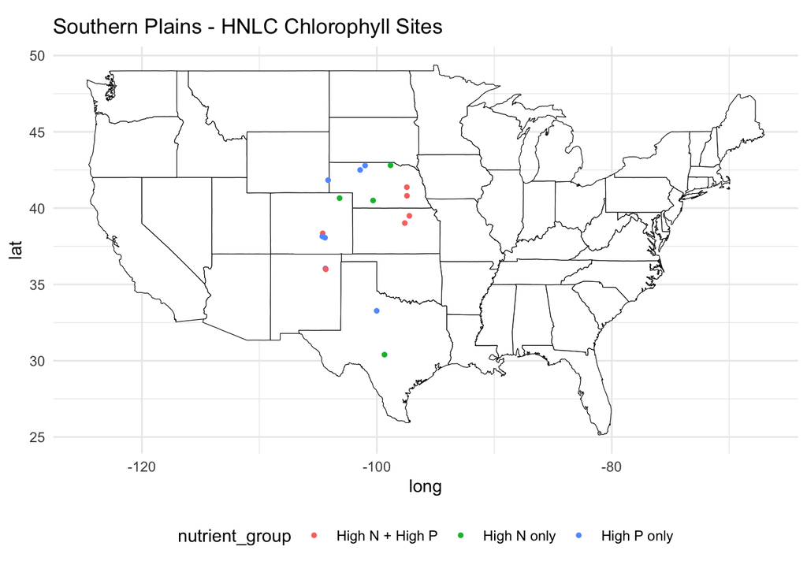

```r
#chlorphyll map
ggplot() +
  geom_polygon(data = us_states,
               aes(x = long, y = lat, group = group),
               fill = "white",
               color = "black",
               linewidth = 0.2) +
  geom_point(data = HNLChlorophyll_sites_list_SPL,
             aes(x = LON_DD83, y = LAT_DD83, color = nutrient_group),
             size = 1) +
  coord_fixed(1.3) +
  ggtitle("Southern Plains - HNLC Chlorophyll Sites") +
  theme_minimal() +
  theme(legend.position = "bottom")
```

```r
##Temperate Plains TPL ----
#Chlorophyll list
HNLChlorophyll_sites_list_TPL <- HNLChlorophyll_sites_TPL %>%
  dplyr::select(
    SITE_ID, LAT_DD83, LON_DD83,
    PTL_RESULT, NTL_RESULT, CHLA_RESULT,
    nutrient_group
  )
table(HNLChlorophyll_sites_list_TPL$nutrient_group)
```

```
##
## High N + High P     High N only     High P only
##               7              10               9
```

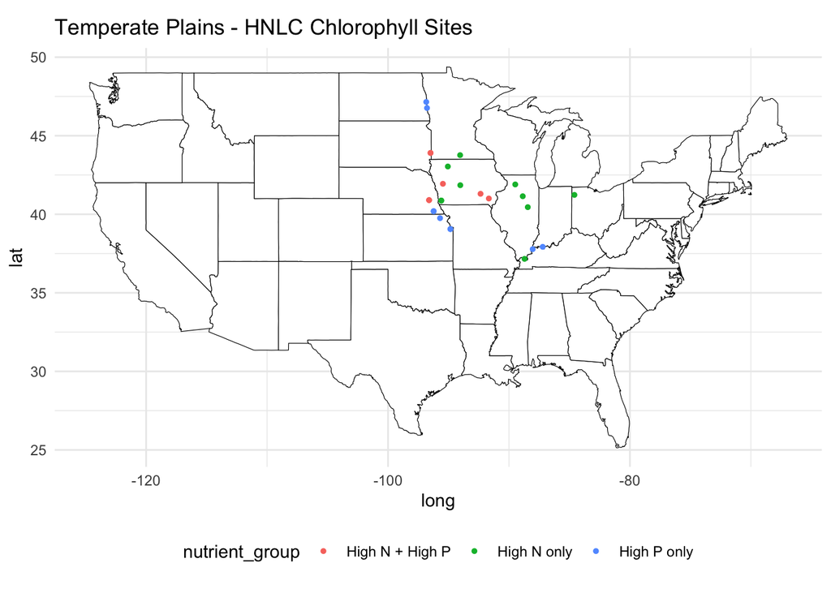

```r
#chlorphyll map
ggplot() +
  geom_polygon(data = us_states,
               aes(x = long, y = lat, group = group),
               fill = "white",
               color = "black",
               linewidth = 0.2) +
  geom_point(data = HNLChlorophyll_sites_list_TPL,
             aes(x = LON_DD83, y = LAT_DD83, color = nutrient_group),
             size = 1) +
  coord_fixed(1.3) +
  ggtitle("Temperate Plains - HNLC Chlorophyll Sites") +
  theme_minimal() +
  theme(legend.position = "bottom")
```

```r
##Coastal Plains CPL ----
#Chlorophyll list
HNLChlorophyll_sites_list_CPL <- HNLChlorophyll_sites_CPL %>%
  dplyr::select(
    SITE_ID, LAT_DD83, LON_DD83,
    PTL_RESULT, NTL_RESULT, CHLA_RESULT,
    nutrient_group
  )
table(HNLChlorophyll_sites_list_CPL$nutrient_group)
```

```
##
## High N + High P     High N only     High P only
##               6               3               7
```

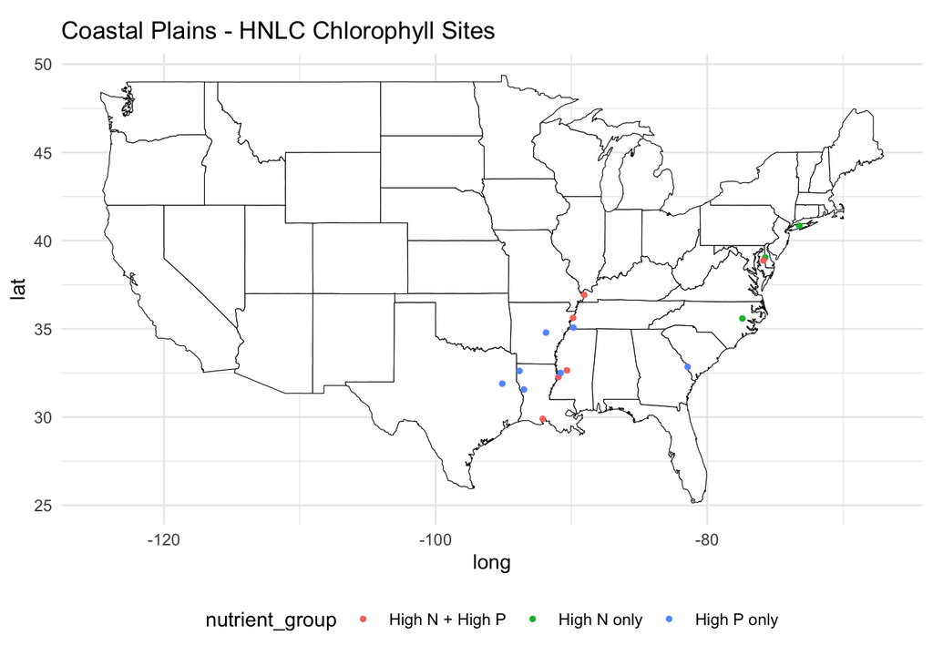

```r
#chlorphyll map
ggplot() +
  geom_polygon(data = us_states,
               aes(x = long, y = lat, group = group),
               fill = "white",
               color = "black",
               linewidth = 0.2) +
  geom_point(data = HNLChlorophyll_sites_list_CPL,
             aes(x = LON_DD83, y = LAT_DD83, color = nutrient_group),
             size = 1) +
  coord_fixed(1.3) +
  ggtitle("Coastal Plains - HNLC Chlorophyll Sites") +
  theme_minimal() +
  theme(legend.position = "bottom")
```

```r
##Upper Midwest UMW ----
#Chlorophyll list
HNLChlorophyll_sites_list_UMW <- HNLChlorophyll_sites_UMW %>%
  dplyr::select(
    SITE_ID, LAT_DD83, LON_DD83,
    PTL_RESULT, NTL_RESULT, CHLA_RESULT,
    nutrient_group
  )
table(HNLChlorophyll_sites_list_UMW$nutrient_group)
```

```
##
## High N + High P     High N only     High P only
##              13               3               6
```

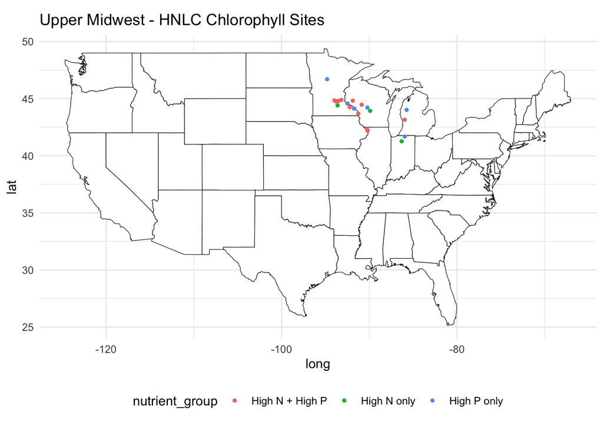

```r
#chlorphyll map
ggplot() +
  geom_polygon(data = us_states,
               aes(x = long, y = lat, group = group),
               fill = "white",
               color = "black",
               linewidth = 0.2) +
  geom_point(data = HNLChlorophyll_sites_list_UMW,
             aes(x = LON_DD83, y = LAT_DD83, color = nutrient_group),
             size = 1) +
  coord_fixed(1.3) +
  ggtitle("Upper Midwest - HNLC Chlorophyll Sites") +
  theme_minimal() +
  theme(legend.position = "bottom")
```

```r
##Southern Appalachians SAP ----
#Chlorophyll list
HNLChlorophyll_sites_list_SAP <- HNLChlorophyll_sites_SAP %>%
  dplyr::select(
    SITE_ID, LAT_DD83, LON_DD83,
    PTL_RESULT, NTL_RESULT, CHLA_RESULT,
    nutrient_group
  )
table(HNLChlorophyll_sites_list_SAP$nutrient_group)
```

```
##
## High N + High P     High N only     High P only
##              10               3              15
```

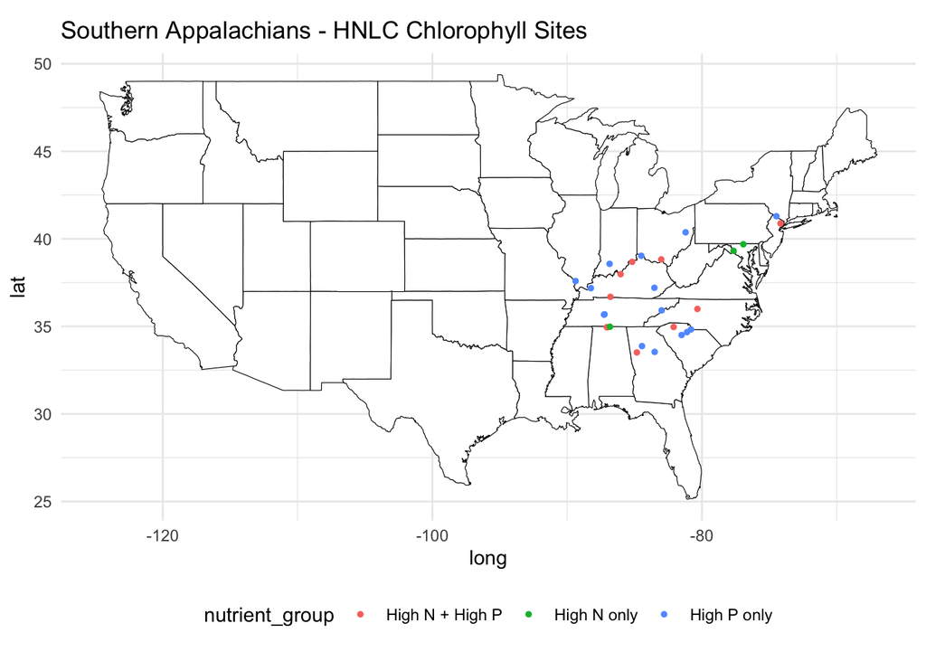

```r
#chlorphyll map
ggplot() +
  geom_polygon(data = us_states,
               aes(x = long, y = lat, group = group),
               fill = "white",
               color = "black",
               linewidth = 0.2) +
  geom_point(data = HNLChlorophyll_sites_list_SAP,
             aes(x = LON_DD83, y = LAT_DD83, color = nutrient_group),
             size = 1) +
  coord_fixed(1.3) +
  ggtitle("Southern Appalachians - HNLC Chlorophyll Sites") +
  theme_minimal() +
  theme(legend.position = "bottom")
```

```r
##Northern Appalachians NAP ----
#Chlorophyll list
HNLChlorophyll_sites_list_NAP <- HNLChlorophyll_sites_NAP %>%
  dplyr::select(
    SITE_ID, LAT_DD83, LON_DD83,
    PTL_RESULT, NTL_RESULT, CHLA_RESULT,
    nutrient_group
  )
table(HNLChlorophyll_sites_list_NAP$nutrient_group)
```

```
##
## High N + High P     High N only     High P only
##               6               5               3
```

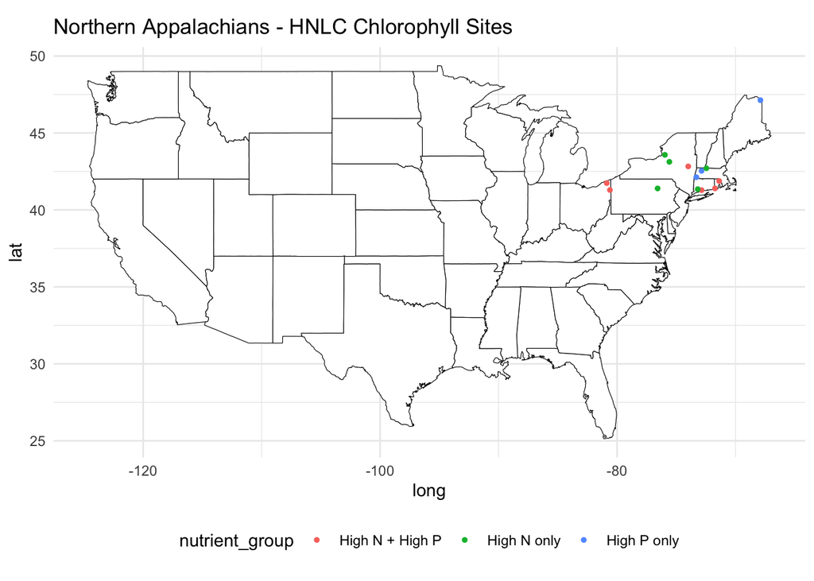

```r
#chlorphyll map
ggplot() +
  geom_polygon(data = us_states,
               aes(x = long, y = lat, group = group),
               fill = "white",
               color = "black",
               linewidth = 0.2) +
  geom_point(data = HNLChlorophyll_sites_list_NAP,
             aes(x = LON_DD83, y = LAT_DD83, color = nutrient_group),
             size = 1) +
  coord_fixed(1.3) +
  ggtitle("Northern Appalachians - HNLC Chlorophyll Sites") +
  theme_minimal() +
  theme(legend.position = "bottom")
```

```r
##Western Mountains WMT ----
#Chlorophyll list
HNLChlorophyll_sites_list_WMT <- HNLChlorophyll_sites_WMT %>%
  dplyr::select(
    SITE_ID, LAT_DD83, LON_DD83,
    PTL_RESULT, NTL_RESULT, CHLA_RESULT,
    nutrient_group
  )
table(HNLChlorophyll_sites_list_WMT$nutrient_group)
```

```
##
## High N + High P     High N only     High P only
##               8               4               8
```

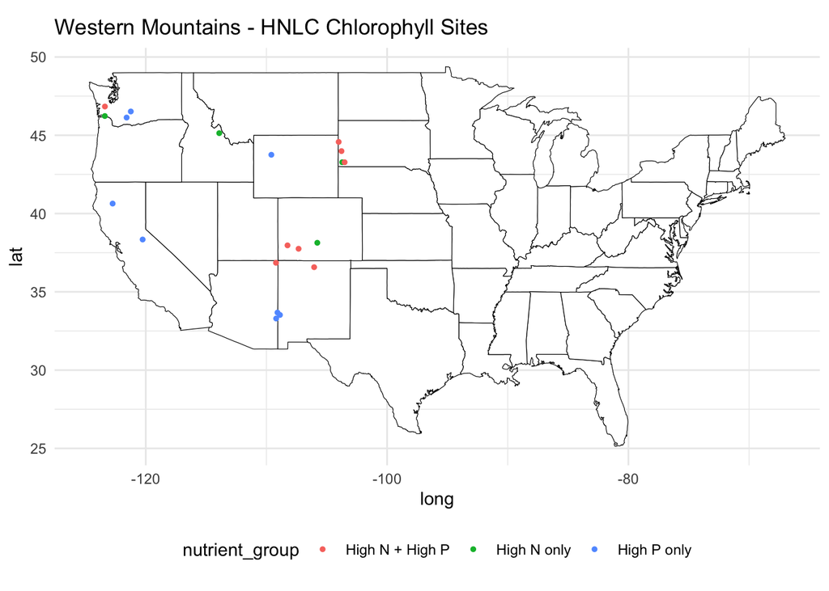

```r
#chlorphyll map
ggplot() +
  geom_polygon(data = us_states,
               aes(x = long, y = lat, group = group),
               fill = "white",
               color = "black",
               linewidth = 0.2) +
  geom_point(data = HNLChlorophyll_sites_list_WMT,
             aes(x = LON_DD83, y = LAT_DD83, color = nutrient_group),
             size = 1) +
  coord_fixed(1.3) +
  ggtitle("Western Mountains - HNLC Chlorophyll Sites") +
  theme_minimal() +
  theme(legend.position = "bottom")
```

```r
##Northern Plains NPL ----
#Chlorophyll list
HNLChlorophyll_sites_list_NPL <- HNLChlorophyll_sites_NPL %>%
  dplyr::select(
    SITE_ID, LAT_DD83, LON_DD83,
    PTL_RESULT, NTL_RESULT, CHLA_RESULT,
    nutrient_group
  )
table(HNLChlorophyll_sites_list_NPL$nutrient_group)
```

```
##
## High N + High P     High N only     High P only
##              11               5               7
```

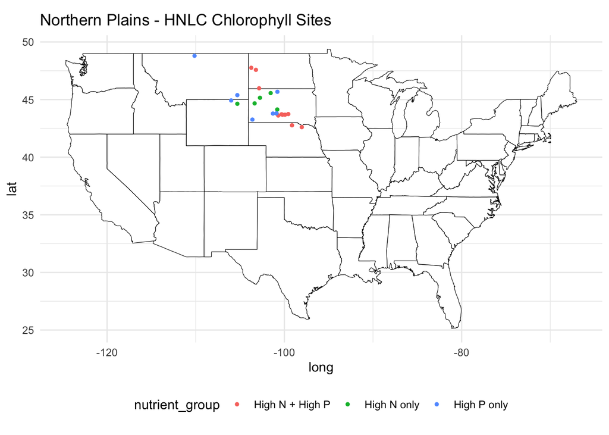

```r
#chlorphyll map
ggplot() +
  geom_polygon(data = us_states,
               aes(x = long, y = lat, group = group),
               fill = "white",
               color = "black",
               linewidth = 0.2) +
  geom_point(data = HNLChlorophyll_sites_list_NPL,
             aes(x = LON_DD83, y = LAT_DD83, color = nutrient_group),
             size = 1) +
  coord_fixed(1.3) +
  ggtitle("Northern Plains - HNLC Chlorophyll Sites") +
  theme_minimal() +
  theme(legend.position = "bottom")
```

```r
##Xeric XER ----
#Chlorophyll list
HNLChlorophyll_sites_list_XER <- HNLChlorophyll_sites_XER %>%
  dplyr::select(
    SITE_ID, LAT_DD83, LON_DD83,
    PTL_RESULT, NTL_RESULT, CHLA_RESULT,
    nutrient_group
  )
table(HNLChlorophyll_sites_list_XER$nutrient_group)
```

```
##
## High N + High P     High N only     High P only
##               7               1              13
```

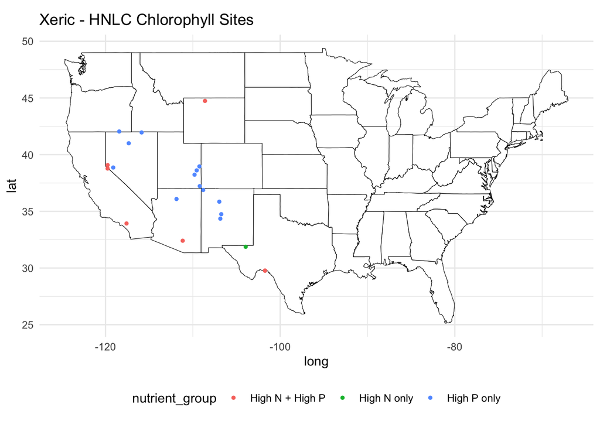

```r
#chlorphyll map
ggplot() +
  geom_polygon(data = us_states,
               aes(x = long, y = lat, group = group),
               fill = "white",
               color = "black",
               linewidth = 0.2) +
  geom_point(data = HNLChlorophyll_sites_list_XER,
             aes(x = LON_DD83, y = LAT_DD83, color = nutrient_group),
             size = 1) +
  coord_fixed(1.3) +
  ggtitle("Xeric - HNLC Chlorophyll Sites") +
  theme_minimal() +
  theme(legend.position = "bottom")
```

```r
#list of all sites by eco region ----
#chlorophyll
HNLChlorophyll_sites_list_SPL$EcoRegion <- "SPL"
HNLChlorophyll_sites_list_TPL$EcoRegion <- "TPL"
HNLChlorophyll_sites_list_CPL$EcoRegion <- "CPL"
HNLChlorophyll_sites_list_UMW$EcoRegion <- "UMW"
HNLChlorophyll_sites_list_SAP$EcoRegion <- "SAP"
HNLChlorophyll_sites_list_NAP$EcoRegion <- "NAP"
HNLChlorophyll_sites_list_WMT$EcoRegion <- "WMT"
HNLChlorophyll_sites_list_NPL$EcoRegion <- "NPL"
HNLChlorophyll_sites_list_XER$EcoRegion <- "XER"

byECO9_HNLChlorophyll_sites <- dplyr::bind_rows(
  HNLChlorophyll_sites_list_SPL,
  HNLChlorophyll_sites_list_TPL,
  HNLChlorophyll_sites_list_CPL,
  HNLChlorophyll_sites_list_UMW,
  HNLChlorophyll_sites_list_SAP,
  HNLChlorophyll_sites_list_NAP,
  HNLChlorophyll_sites_list_WMT,
  HNLChlorophyll_sites_list_NPL,
  HNLChlorophyll_sites_list_XER
)
```

#List of all Eco 9 sites

```r
byECO9_HNLChlorophyll_sites <- byECO9_HNLChlorophyll_sites %>%
  left_join(
    HNLC_data %>% select(SITE_ID, COMID, HUC8),
    by = "SITE_ID")
byECO9_HNLChlorophyll_sites <- byECO9_HNLChlorophyll_sites %>%
  mutate(HUC8_clean = sub("^H", "", HUC8))
```

#HNLC spot in USA across the 9 ecoregions

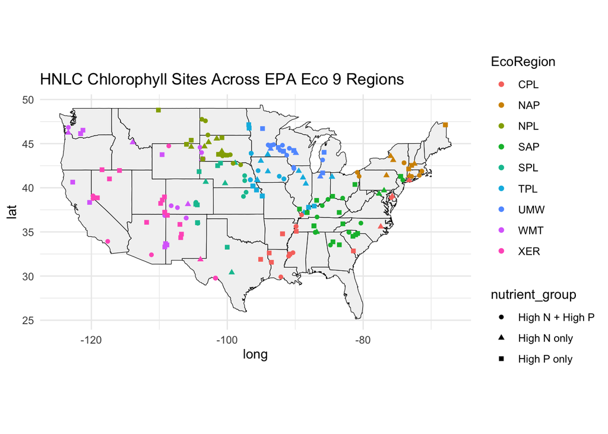

```r
#chlorophyll map by eco region
ggplot() +
  geom_polygon(data = us_states,
               aes(x = long, y = lat, group = group),
               fill = "gray95",
               color = "black",
               linewidth = 0.2) +
  geom_point(data = byECO9_HNLChlorophyll_sites,
             aes(x = LON_DD83,
                 y = LAT_DD83,
                 color = EcoRegion,
                 shape = nutrient_group),
             size = 1.5) +
  coord_fixed(1.3) +
  theme_minimal() +
  ggtitle("HNLC Chlorophyll Sites Across EPA Eco 9 Regions") +
  theme(legend.position = "right")
```

#excel sheet for HNLC

```r
write_xlsx(byECO9_HNLChlorophyll_sites,
  "HNLChlorophyll_sites.xlsx")
```

#box plots of the ot C,N, and P

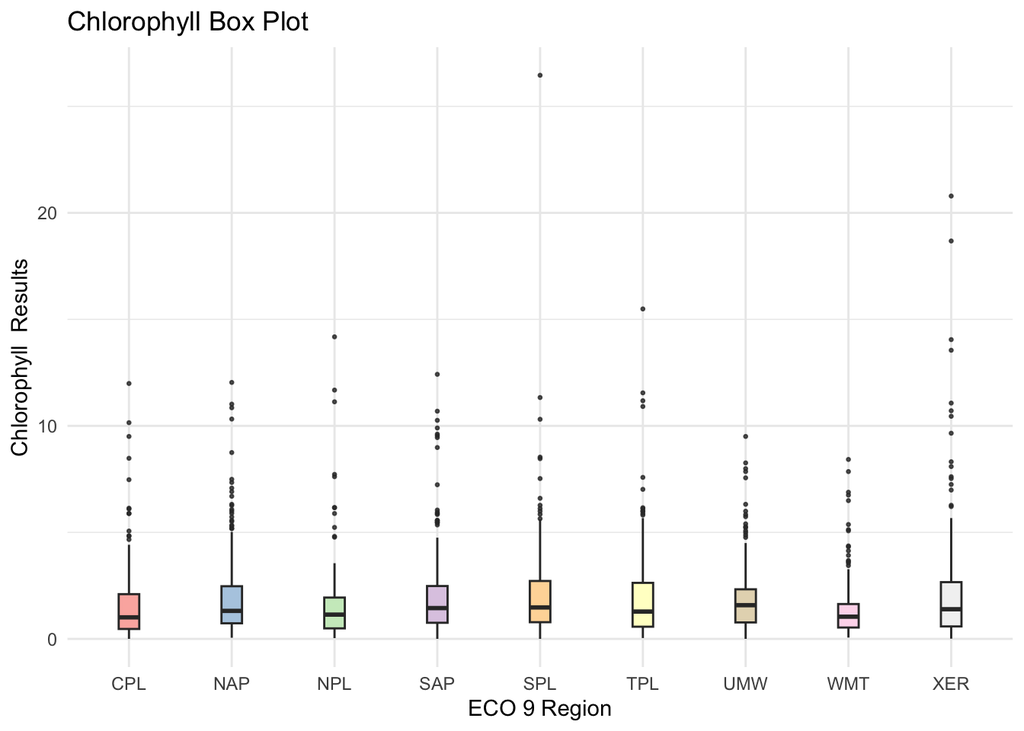

```r
# Box plots

ggplot(data = HNLC_data, aes(x = AG_ECO9, y = CHLA_RESULT, fill = AG_ECO9)) +
  geom_boxplot(width = 0.2,
               outlier.size = 0.5,      #smaller dots
               outlier.alpha = 0.8) + #transparent
  scale_fill_brewer(palette = "Pastel1") +
  labs(title = "Chlorophyll Box Plot",
       y = "Chlorophyll  Results",
       x = "ECO 9 Region") +
  theme_minimal()+
  theme(legend.position = "none")
```

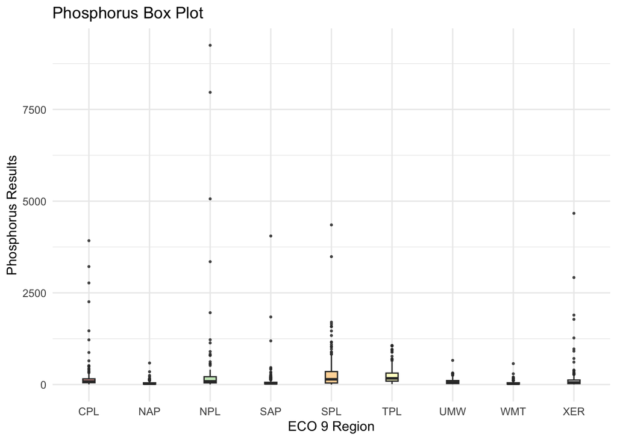

```r
ggplot(data = HNLC_data, aes(x = AG_ECO9, y = PTL_RESULT, fill = AG_ECO9)) +
  geom_boxplot(width = 0.2,
               outlier.size = 0.5,      #smaller dots
               outlier.alpha = 0.8) + #transparent
  scale_fill_brewer(palette = "Pastel1") +
  labs(title = "Phosphorus Box Plot ",
       y = "Phosphorus Results",
       x = "ECO 9 Region") +
  theme_minimal()+
  theme(legend.position = "none")
```

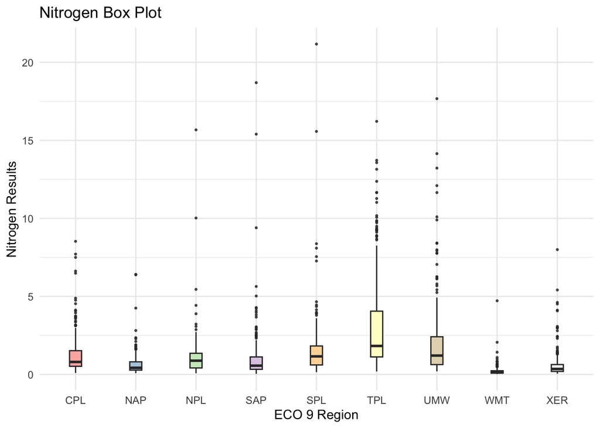

```r
ggplot(data = HNLC_data, aes(x = AG_ECO9, y = NTL_RESULT, fill = AG_ECO9)) +
  geom_boxplot(width = 0.2,
               outlier.size = 0.5,      #smaller dots
               outlier.alpha = 0.8) + #transparent
  scale_fill_brewer(palette = "Pastel1") +
  labs(title = "Nitrogen Box Plot",
       y = "Nitrogen Results",
       x = "ECO 9 Region") +
  theme_minimal()+
  theme(legend.position = "none")
```

#stat test for HNLC Kruskal-Wallis test to see if they vary statistcal

```r
kruskal.test(CHLA_RESULT ~ AG_ECO9, data = HNLC_data)
```

```
##
##  Kruskal-Wallis rank sum test
##
## data:  CHLA_RESULT by AG_ECO9
## Kruskal-Wallis chi-squared = 42.823, df = 8, p-value = 9.483e-07
```

```r
kruskal.test(PTL_RESULT ~ AG_ECO9, data = HNLC_data)
```

```
##
##  Kruskal-Wallis rank sum test
##
## data:  PTL_RESULT by AG_ECO9
## Kruskal-Wallis chi-squared = 662.25, df = 8, p-value < 2.2e-16
```

```r
kruskal.test(NTL_RESULT ~ AG_ECO9, data = HNLC_data)
```

```
##
##  Kruskal-Wallis rank sum test
##
## data:  NTL_RESULT by AG_ECO9
## Kruskal-Wallis chi-squared = 855.6, df = 8, p-value < 2.2e-16
```

Pot hoc test for kruskal wallace (Dunn test )

```r
dunnTest(CHLA_RESULT ~ AG_ECO9, data = HNLC_data, method = "bh")
```

```
## Dunn (1964) Kruskal-Wallis multiple comparison
```

```
##   p-values adjusted with the Benjamini-Hochberg method.
```

```
##    Comparison           Z      P.unadj        P.adj
## 1   CPL - NAP -3.09586017 1.962429e-03 0.0078497153
## 2   CPL - NPL -0.47889091 6.320162e-01 0.7845718794
## 3   NAP - NPL  2.23476052 2.543308e-02 0.0572244193
## 4   CPL - SAP -3.96653681 7.292452e-05 0.0013126413
## 5   NAP - SAP -0.76394683 4.448989e-01 0.5931985702
## 6   NPL - SAP -2.95691909 3.107296e-03 0.0111862670
## 7   CPL - SPL -3.53659820 4.053158e-04 0.0024318948
## 8   NAP - SPL -0.81426938 4.154906e-01 0.5983065309
## 9   NPL - SPL -2.75157219 5.930995e-03 0.0152511290
## 10  SAP - SPL -0.16998498 8.650219e-01 0.9159055909
## 11  CPL - TPL -2.57800749 9.937184e-03 0.0238492427
## 12  NAP - TPL  0.45618343 6.482581e-01 0.7779096996
## 13  NPL - TPL -1.79880664 7.204927e-02 0.1440985458
## 14  SAP - TPL  1.21890746 2.228793e-01 0.4011827752
```

[output cut: 22 more lines]

```r
dunnTest(PTL_RESULT ~ AG_ECO9, data = HNLC_data, method = "bh")
```

```
## Dunn (1964) Kruskal-Wallis multiple comparison
##   p-values adjusted with the Benjamini-Hochberg method.
```

```
##    Comparison            Z      P.unadj        P.adj
## 1   CPL - NAP  12.62842771 1.471899e-36 8.831393e-36
## 2   CPL - NPL  -0.05339309 9.574187e-01 9.847735e-01
## 3   NAP - NPL -11.00800604 3.496565e-28 1.398626e-27
## 4   CPL - SAP   9.73477367 2.142942e-22 7.013265e-22
## 5   NAP - SAP  -3.38308102 7.167748e-04 9.215676e-04
## 6   NPL - SAP   8.41397200 3.963554e-17 1.019200e-16
## 7   CPL - SPL  -2.23320618 2.553535e-02 2.872727e-02
## 8   NAP - SPL -13.64928053 2.038815e-42 1.834934e-41
## 9   NPL - SPL  -1.93043792 5.355260e-02 5.842102e-02
## 10  SAP - SPL -11.03832640 2.496395e-28 1.123378e-27
## 11  CPL - TPL  -6.17115756 6.779183e-10 1.284477e-09
## 12  NAP - TPL -18.65075410 1.245087e-77 4.482313e-76
## 13  NPL - TPL  -5.30291232 1.139697e-07 1.709545e-07
## 14  SAP - TPL -16.01998701 9.266964e-58 1.112036e-56
```

[output cut: 22 more lines]

```r
dunnTest(NTL_RESULT ~ AG_ECO9, data = HNLC_data, method = "bh")
```

```
## Dunn (1964) Kruskal-Wallis multiple comparison
##   p-values adjusted with the Benjamini-Hochberg method.
```

```
##    Comparison           Z       P.unadj         P.adj
## 1   CPL - NAP   6.7979662  1.061063e-11  1.909914e-11
## 2   CPL - NPL   0.8550622  3.925167e-01  4.037315e-01
## 3   NAP - NPL  -5.0442838  4.552232e-07  7.125233e-07
## 4   CPL - SAP   4.3621170  1.288099e-05  1.717466e-05
## 5   NAP - SAP  -2.6889500  7.167715e-03  8.063679e-03
## 6   NPL - SAP   2.8693449  4.113230e-03  4.776654e-03
## 7   CPL - SPL  -2.5479303  1.083641e-02  1.182154e-02
## 8   NAP - SPL  -8.6868237  3.727138e-18  9.584070e-18
## 9   NPL - SPL  -3.0500297  2.288188e-03  2.745825e-03
## 10  SAP - SPL  -6.5356800  6.332119e-11  1.036165e-10
## 11  CPL - TPL  -8.0793750  6.509957e-16  1.464740e-15
## 12  NAP - TPL -14.7734418  2.173253e-49  1.303952e-48
## 13  NPL - TPL  -7.8615826  3.793103e-15  8.032453e-15
## 14  SAP - TPL -12.6684505  8.844421e-37  3.537768e-36
```

[output cut: 22 more lines]

#getting letter for the dunn test

```r
get_letters <- function(formula, data){

  dunn <- dunnTest(formula, data = data, method = "bh")$res

  # Fix comparison format
  dunn$Comparison <- gsub(" - ", "-", dunn$Comparison)

  # Create named vector of p-values
  pvals <- dunn$P.adj
  names(pvals) <- dunn$Comparison

  # Generate letters
  letters <- multcompView::multcompLetters(pvals, threshold = 0.05)

  # Convert to dataframe
  cld <- data.frame(
    Group = names(letters$Letters),
    Letter = letters$Letters
  )

  return(cld)
}

cld_CHLA <- get_letters(CHLA_RESULT ~ AG_ECO9, HNLC_data)
cld_PTL  <- get_letters(PTL_RESULT ~ AG_ECO9, HNLC_data)
cld_NTL  <- get_letters(NTL_RESULT ~ AG_ECO9, HNLC_data)
```

#plot with letters

this is just to confirm there a reason to break up HNLC sites by eco regions

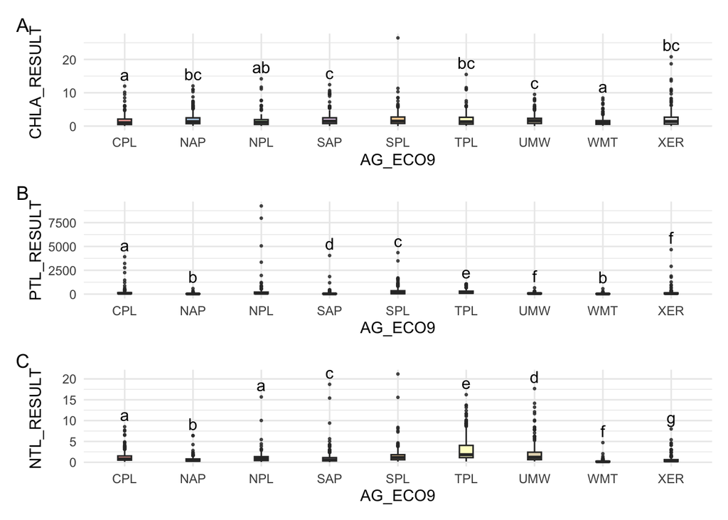

```r
HNLC_data$AG_ECO9 <- factor(HNLC_data$AG_ECO9)
label_pos_CHLA <- HNLC_data %>%
  group_by(AG_ECO9) %>%
  summarise(y = max(CHLA_RESULT, na.rm = TRUE))

label_pos_PTL <- HNLC_data %>%
  group_by(AG_ECO9) %>%
  summarise(y = max(PTL_RESULT, na.rm = TRUE))

label_pos_NTL <- HNLC_data %>%
  group_by(AG_ECO9) %>%
  summarise(y = max(NTL_RESULT, na.rm = TRUE))

# Join letters
plot_labels_CHLA <- left_join(cld_CHLA, label_pos_CHLA, by = c("Group" = "AG_ECO9"))
plot_labels_PTL  <- left_join(cld_PTL,  label_pos_PTL,  by = c("Group" = "AG_ECO9"))
plot_labels_NTL  <- left_join(cld_NTL,  label_pos_NTL,  by = c("Group" = "AG_ECO9"))

PCHLA <- ggplot(HNLC_data, aes(x = AG_ECO9, y = CHLA_RESULT, fill = AG_ECO9)) +
  geom_boxplot(width = 0.2, outlier.size = 0.5, outlier.alpha = 0.8) +
  geom_text(data = plot_labels_CHLA,
            aes(x = Group, y = y, label = Letter),
            inherit.aes = FALSE,
            vjust = -0.5, size = 4) +
  scale_fill_brewer(palette = "Pastel1") +
  theme_minimal() +
  theme(legend.position = "none")

PPTL <- ggplot(HNLC_data, aes(x = AG_ECO9, y = PTL_RESULT, fill = AG_ECO9)) +
  geom_boxplot(width = 0.2, outlier.size = 0.5, outlier.alpha = 0.8) +
  geom_text(data = plot_labels_PTL,
            aes(x = Group, y = y, label = Letter),
            inherit.aes = FALSE,
            vjust = -0.5, size = 4) +
  scale_fill_brewer(palette = "Pastel1") +
  theme_minimal() +
  theme(legend.position = "none")

PNTL <- ggplot(HNLC_data, aes(x = AG_ECO9, y = NTL_RESULT, fill = AG_ECO9)) +
  geom_boxplot(width = 0.2, outlier.size = 0.5, outlier.alpha = 0.8) +
  geom_text(data = plot_labels_NTL,
            aes(x = Group, y = y, label = Letter),
            inherit.aes = FALSE,
            vjust = -0.5, size = 4) +
  scale_fill_brewer(palette = "Pastel1") +
  theme_minimal() +
  theme(legend.position = "none")


combined_plot <- PCHLA / PPTL / PNTL +
  plot_annotation(tag_levels = "A")

combined_plot
```

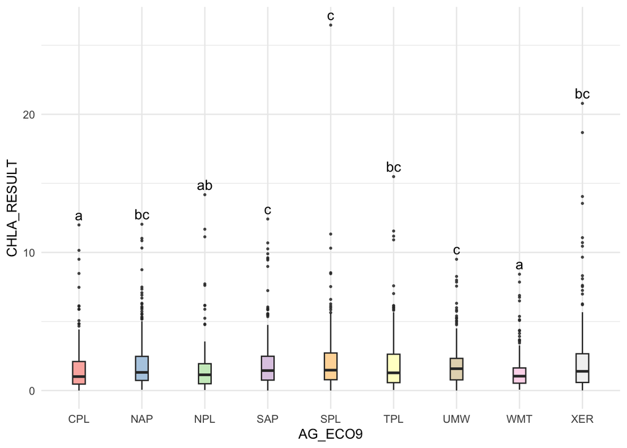

```r
PCHLA
```

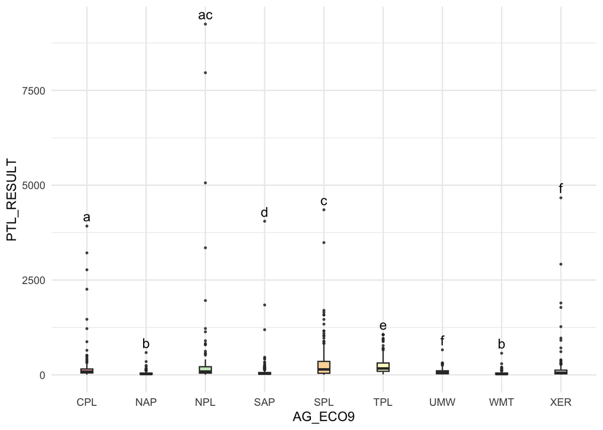

```r
PPTL
```

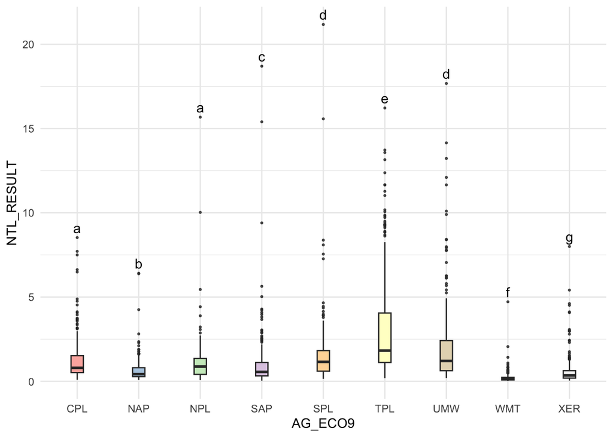

```r
PNTL
```

#Finding metal limitation

```r
#filter out low metals (lit based----

Iron_low <- Iron_2018_2019 %>%
  filter(DetectionQuantitationLimitMeasure.MeasureValue.Clean.UGL < 10)

Manganese_low <- Manganese_2018_2019 %>%
  filter(DetectionQuantitationLimitMeasure.MeasureValue.Clean.UGL < 1)

Nickel_low <- Nickel_2018_2019 %>%
  filter(DetectionQuantitationLimitMeasure.MeasureValue.Clean.UGL < 1.4)

Zinc_low <- Zinc_2018_2019 %>%
  filter(DetectionQuantitationLimitMeasure.MeasureValue.Clean.UGL < 5)

#combine low metals into one set ----
Iron_low$Metal <- "Iron"
Manganese_low$Metal <- "Manganese"
Nickel_low$Metal <- "Nickel"
Zinc_low$Metal <- "Zinc"

Iron_low$HUCEightDigitCode <- as.character(Iron_low$HUCEightDigitCode)
Manganese_low$HUCEightDigitCode <- as.character(Manganese_low$HUCEightDigitCode)
Nickel_low$HUCEightDigitCode <- as.character(Nickel_low$HUCEightDigitCode)
Zinc_low$HUCEightDigitCode <- as.character(Zinc_low$HUCEightDigitCode)

metals_low <- dplyr::bind_rows(
  Iron_low, Manganese_low,
  Nickel_low, Zinc_low)
```

#Low metal map

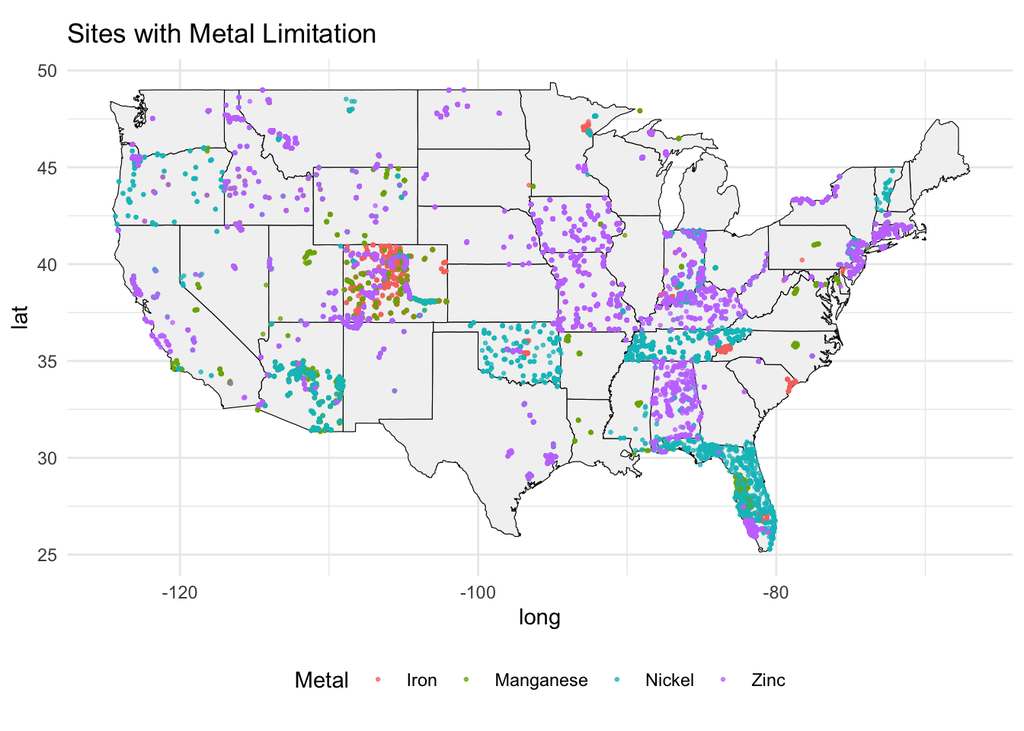

```r
ggplot() +
  geom_polygon(data = us_states,
               aes(x = long, y = lat, group = group),
               fill = "gray95",
               color = "black",
               linewidth = 0.2) +
  geom_point(data = metals_low,
             aes(x = lon.Clean, y = lat.Clean, color = Metal),
             size = .5,
             alpha = 0.7) +
  coord_fixed(1.3) +
  theme_minimal() +
  labs(color = "Metal",
       title = paste0("Sites with Metal Limitation")) +
  theme(legend.position = "bottom")
```

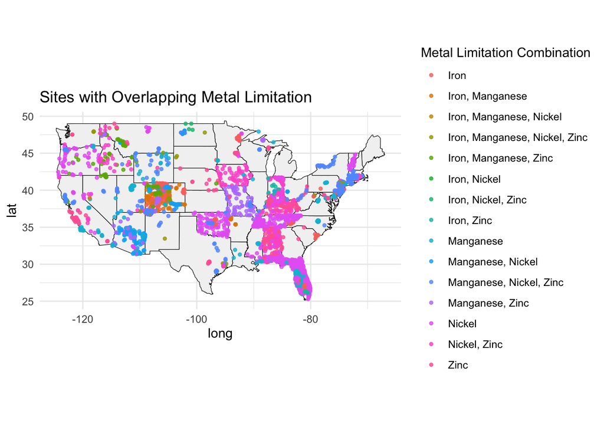

```r
metals_low_summary <- metals_low %>%
  group_by(MonitoringLocationIdentifier, lat.Clean, lon.Clean) %>%
  summarise(
    metals_present = paste(sort(unique(Metal)), collapse = ", "),
    n_metals = n_distinct(Metal),
    .groups = "drop"
  )

ggplot() +
  geom_polygon(data = us_states,
               aes(x = long, y = lat, group = group),
               fill = "gray95",
               color = "black",
               linewidth = 0.2) +
  geom_point(data = metals_low_summary,
             aes(x = lon.Clean, y = lat.Clean, color = metals_present),
             size = 1,
             alpha = 0.8) +
  coord_fixed(1.3) +
  theme_minimal() +
  labs(color = "Metal Limitation Combination",
       title = "Sites with Overlapping Metal Limitation") +
  theme(legend.position = "right")
```

#Mapping metal and nurtients on same map

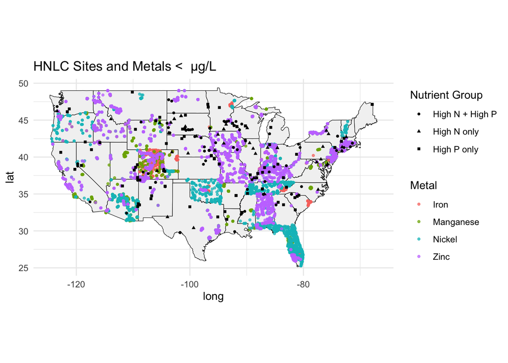

```r
ggplot() +
  # base map
  geom_polygon(data = us_states,
               aes(x = long, y = lat, group = group),
               fill = "gray95",
               color = "black",
               linewidth = 0.2) +

  # metals (colored by metal)
  geom_point(data = metals_low,
             aes(x = lon.Clean, y = lat.Clean, color = Metal),
             size = 0.8,
             alpha = 0.7) +

  # chlorophyll sites (shaped by nutrient group)
  geom_point(data = byECO9_HNLChlorophyll_sites,
             aes(x = LON_DD83,
                 y = LAT_DD83,
                 shape = nutrient_group),
             color = "black",
             size = 1) +

  coord_fixed(1.3) +
  theme_minimal() +
  labs(title = paste0("HNLC Sites and Metals <  µg/L"),
       color = "Metal",
       shape = "Nutrient Group") +
  theme(legend.position = "right")
```

#Finding the Overlap between HNLC and metals by HUC8

```r
overlap_huc8 <- metals_low %>%
  inner_join(byECO9_HNLChlorophyll_sites,
             by = c("HUCEightDigitCode" = "HUC8_clean"))
overlap_huc8_Clean <- overlap_huc8 %>%
  group_by(MonitoringLocationIdentifier,
           lat.Clean,
           lon.Clean,
           nutrient_group) %>%

  summarise(
    metals_present = paste(sort(unique(Metal)), collapse = ", "),
    .groups = "drop"
  )
```

#mapping overlapped sites

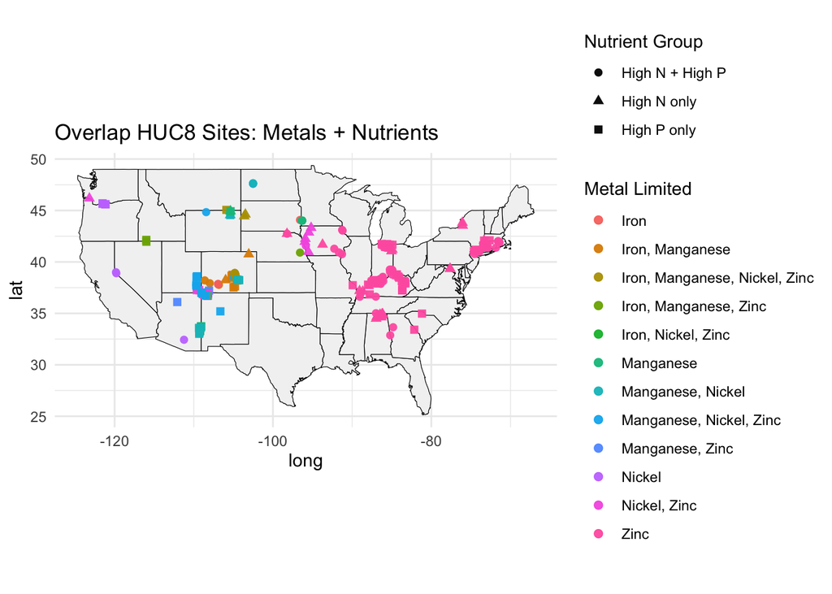

```r
ggplot() +
  geom_polygon(data = us_states,
               aes(x = long, y = lat, group = group),
               fill = "gray95",
               color = "black",
               linewidth = 0.2) +

  geom_point(data = overlap_huc8_Clean,
             aes(x = lon.Clean,
                 y = lat.Clean,
                 color = metals_present,
                 shape = nutrient_group),
             size = 2,
             alpha = 0.95) +

  coord_fixed(1.3) +
  theme_minimal() +
  labs(title = "Overlap HUC8 Sites: Metals + Nutrients",
       color = "Metal Limited",
       shape = "Nutrient Group") +
  theme(legend.position = "right")
```

#COMID Overlap

```r
overlap_COMID <- metals_low %>%
  inner_join(byECO9_HNLChlorophyll_sites, by = "COMID")
overlap_COMID_Clean <- overlap_COMID %>%
  group_by(MonitoringLocationIdentifier,
           lat.Clean,
           lon.Clean,
           nutrient_group) %>%

  summarise(
    metals_present = paste(sort(unique(Metal)), collapse = ", "),
    .groups = "drop"
  )
```

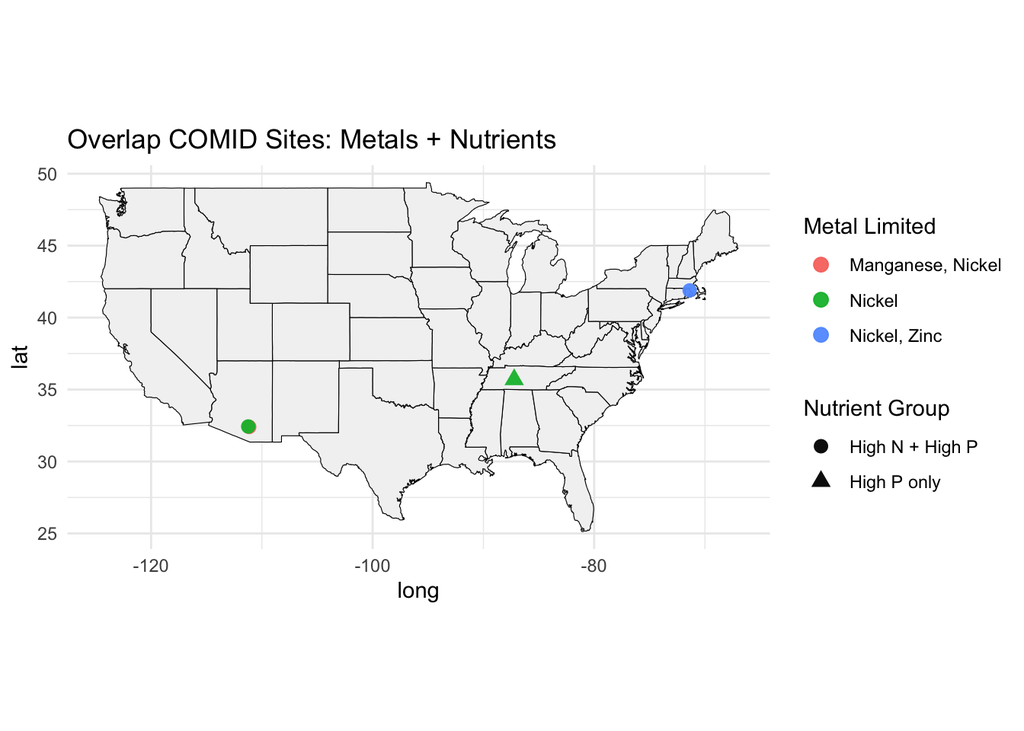

```r
ggplot() +
  geom_polygon(data = us_states,
               aes(x = long, y = lat, group = group),
               fill = "gray95",
               color = "black",
               linewidth = 0.2) +

  geom_point(data = overlap_COMID_Clean,
             aes(x = lon.Clean,
                 y = lat.Clean,
                 color = metals_present,
                 shape = nutrient_group),
             size = 3,
             alpha = 0.95) +

  coord_fixed(1.3) +
  theme_minimal() +
  labs(title = "Overlap COMID Sites: Metals + Nutrients",
       color = "Metal Limited",
       shape = "Nutrient Group") +
  theme(legend.position = "right")
```

#finding the site info back in the orginal data (HUC8)

```r
site_lookup_full <- function(site_id) {

  # get overlap info (finding SITE_ID)
  overlap_info <- overlap_huc8 %>%
    filter(MonitoringLocationIdentifier == site_id)

  # extract SITE_ID
  site_ids <- overlap_info %>%
    pull(SITE_ID) %>%
    unique()

  # pull full data
  eco9_info <- HNLC_data %>%
    filter(SITE_ID %in% site_ids)

  # put it in
  list(
    overlap_data = overlap_info,
    Site_data = eco9_info
  )
}

# Change the "___"based on MonitoringLocationIdentifier
site_lookup_full("1119USBR_WQX-DVO112")
```

```
## $overlap_data
##   CharacteristicName lat.Clean lon.Clean HorizontalCollectionMethodName
## 1               Iron  42.14383 -115.9978                GPS-Unspecified
## 2          Manganese  42.14383 -115.9978                GPS-Unspecified
## 3               Zinc  42.14383 -115.9978                GPS-Unspecified
##   HorizontalCoordinateReferenceSystemDatumName ActivityStartDate
## 1                                        WGS84        2019-08-28
## 2                                        WGS84        2019-08-28
## 3                                        WGS84        2019-08-28
##   ResultSampleFractionText.Clean MonitoringLocationIdentifier
## 1                          total          1119USBR_WQX-DVO112
## 2                          total          1119USBR_WQX-DVO112
## 3                          total          1119USBR_WQX-DVO112
##   ResultAnalyticalMethod.MethodName MonitoringLocationTypeName
## 1        Metals in Water by ICP-AES               River/Stream
## 2        Metals in Water by ICP-AES               River/Stream
## 3        Metals in Water by ICP-AES               River/Stream
##   HUCEightDigitCode flag_coord_consensus flag_coord_recency
## 1          17050102                FALSE              FALSE
## 2          17050102                FALSE              FALSE
## 3          17050102                FALSE              FALSE
##   flag_mli_consolidated flag_dl_recovered flag_value_averaged
## 1                 FALSE             FALSE               FALSE
## 2                 FALSE             FALSE               FALSE
## 3                 FALSE             FALSE               FALSE
##   flag_dissolved_gt_total flag_outlier_high OrganizationFormalName
## 1                   FALSE             FALSE  Bureau of Reclamation
## 2                   FALSE             FALSE  Bureau of Reclamation
## 3                   FALSE             FALSE  Bureau of Reclamation
##   OrganizationIdentifier.Clean     MW
## 1                     1119usbr 55.845
## 2                     1119usbr 54.938
## 3                     1119usbr 65.380
##   DetectionQuantitationLimitMeasure.MeasureValue.Clean.UGL  COMID.x StreamOrde
## 1                                                      0.5 23288369          1
## 2                                                      0.5 23288369          1
## 3                                                      4.0 23288369          1
##       Metal        SITE_ID LAT_DD83  LON_DD83 PTL_RESULT NTL_RESULT CHLA_RESULT
## 1      Iron NRS18_NV_10009 41.95829 -115.8645    176.055      0.409      0.5048
## 2 Manganese NRS18_NV_10009 41.95829 -115.8645    176.055      0.409      0.5048
```

[output cut: 28 more lines]

```
## 1   Nevada  Include   F32007         1 SmallStreams         1      NV  Target
##   URBN_NRS08 URBN_NRS18 US_L3CODE                US_L3NAME US_L4CODE
## 1  Non-Urban  Non-Urban        80 Northern Basin and Range       80j
##          US_L4NAME           USFS           WGT_CAT WGT_DSGN WGT_TP_EXTENT
## 1 Semiarid Uplands Forest_Service NV_SS_XER_Include     3170      252.8608
##     XCOORD   YCOORD WGT_TP_CORE AMMONIA_N_RESULT AMMONIA_N_UNITS
## 1 -1623274 669734.4    834.4407            0.011          mg N/L
##   NITRATE_N_RESULT NITRATE_N_UNITS NITRITE_N_RESULT NITRITE_N_UNITS
## 1           0.0027          mg N/L
##   NITRATE_NITRITE_N_RESULT NITRATE_NITRITE_N_UNITS NTL_RESULT NTL_UNITS
## 1                       NA                              0.409    mg N/L
##   NTL_DISS_RESULT NTL_DISS_UNITS TKN_RESULT TKN_UNITS PTL_RESULT PTL_UNITS
## 1           0.251         mg N/L                         176.055      ug/L
##   PTL_DISS_RESULT PTL_DISS_UNITS CHLA_RESULT CHLA_UNITS
## 1         106.897           ug/L      0.5048     ug/cm2
```

```r
site_lookup_full_COMID <- function(site_id) {

  # get overlap info (finding SITE_ID)
  overlap_info <- overlap_huc8 %>%
    filter(MonitoringLocationIdentifier == site_id)

  #extract SITE_ID
  site_ids <- overlap_info %>%
    pull(SITE_ID) %>%
    unique()

  # pull full data
  eco9_info <- HNLC_data %>%
    filter(SITE_ID %in% site_ids)

  # put it in
  list(
    overlap_data = overlap_info,
    Site_data = eco9_info
  )
}

# Change the "___" based on MonitoringLocationIdentifier
site_lookup_full_COMID("USGS-01113895")
```

```
## $overlap_data
##    CharacteristicName lat.Clean lon.Clean HorizontalCollectionMethodName
## 1                Zinc  41.88843 -71.38144         Interpolated from MAP.
## 2                Zinc  41.88843 -71.38144         Interpolated from MAP.
## 3                Zinc  41.88843 -71.38144         Interpolated from MAP.
## 4                Zinc  41.88843 -71.38144         Interpolated from MAP.
## 5                Zinc  41.88843 -71.38144         Interpolated from MAP.
## 6                Zinc  41.88843 -71.38144         Interpolated from MAP.
## 7                Zinc  41.88843 -71.38144         Interpolated from MAP.
## 8                Zinc  41.88843 -71.38144         Interpolated from MAP.
## 9                Zinc  41.88843 -71.38144         Interpolated from MAP.
## 10               Zinc  41.88843 -71.38144         Interpolated from MAP.
## 11               Zinc  41.88843 -71.38144         Interpolated from MAP.
## 12               Zinc  41.88843 -71.38144         Interpolated from MAP.
## 13               Zinc  41.88843 -71.38144         Interpolated from MAP.
```

[output cut: 232 more lines]